# Fast Track 4 - ResNet implementation for multivariate data series

Mateusz Zagórski

2023-05-12

## Założenia projektowe

W ramach zadania należało w ściśle określony sposób przygotować szeregi czasowe o różnej tematyce i wielkości dostępne pod adresem: https://timeseriesclassification.com/Downloads/. Przetworzone szeregi czasowe miały zostać wykorzystane do wyuczenia sieci neuronowej, której zbudowanie przy użyciu interfejsu Keras do platformy TensorFlow było głównym założeniem projektu.

## Przygotowanie danych

Do pobrania danych i manipulacji nimi w lokalnym systemie plików przygotowano dwa skrypty implementujące ten sam interfejs. Pierwszy z nich - `ResNet_data_interactive.R` posiada funkcje, które umożliwiają interakcję użytkownika poprzez konsolę, natomiast drugi - `ResNet_data_utilities.R` wymaga podania wszystkich parametrów w argumentach wywołania funkcji. Metody interaktywne powinny być wywoływane bez argumentów. Funkcja `read_data` powoduje pobranie danych z bazy oraz zwraca skonwertowane do ramek danych szeregi czasowe. Funkcja `get_data` Korzystając z reszty zaimplementowanych w skrypcie funkcji odpowiednio ucina dane oraz zapisuje je w odpowiednim formacie na dysku lub pobiera ucięte już dane z dysku lokalnego. Usunięte dane są uzupełniane wartością `-1`.

## Implementacja sieci

Funkcje związane z modelowaniem sieci ResNet i przygotowywaniem danych, aby były zgodne z wejściem modelu zostały zaimplementowane w skrypcie o nazwie `ResNet_models.R`. Zostały przewidziane dwie różne sieci ResNet - pierwsza z nich (budowana funkcją `resnet`) jest połączeniem wielu różnych źródeł i umożliwia szeroką parametryzację (np. ilości bloków), natomiast druga (budowana funkcją `resnet_hfawaz`) jest wiernym odzwierciedleniem sieci ResNet dostępnej na koncie GitHub użytkownika `hfawaz`. Ten sam skrypt posiada odpowiednio sparametryzowane funkcje umożliwiające trenowanie oraz ewaluację sieci zarówno na danych wybrakowanych, jak i pełnych. Dane wczytane do treningu modelu są wstępnie przetwarzane funkcją `data_preprocessing`. Odbywają się w niej między innymi konwersje, zmiany wymiarowości, mieszanie, uzupełnianie i obcinanie szeregów zarówno w przypadku zbioru testowego, jak i uczącego.

Poniżej zamieszczono reprezentację warstw sieci, na której przeprowadzono większość testów:

```
_____________________________________________________________________________________________________________________________________________________
 Layer (type)                                Output Shape                  Param #          Connected to                                  Trainable
=====================================================================================================================================================
 input_17 (InputLayer)                       [(None, 337, 1)]              0                []                                            Y
 conv1d_160 (Conv1D)                         (None, 337, 64)               512              ['input_17[0][0]']                            Y
 batch_normalization_172 (BatchNormalization  (None, 337, 64)              256              ['conv1d_160[0][0]']                          Y
 )
 activation_136 (Activation)                 (None, 337, 64)               0                ['batch_normalization_172[0][0]']             Y
 conv1d_161 (Conv1D)                         (None, 337, 64)               12288            ['activation_136[0][0]']                      Y
 batch_normalization_173 (BatchNormalization  (None, 337, 64)              256              ['conv1d_161[0][0]']                          Y
 )
 activation_137 (Activation)                 (None, 337, 64)               0                ['batch_normalization_173[0][0]']             Y
 dropout_24 (Dropout)                        (None, 337, 64)               0                ['activation_137[0][0]']                      Y
 conv1d_162 (Conv1D)                         (None, 337, 64)               12288            ['dropout_24[0][0]']                          Y
 batch_normalization_174 (BatchNormalization  (None, 337, 64)              256              ['conv1d_162[0][0]']                          Y
 )
 dropout_25 (Dropout)                        (None, 337, 64)               0                ['batch_normalization_174[0][0]']             Y
 add_48 (Add)                                (None, 337, 64)               0                ['dropout_25[0][0]',                          Y
                                                                                             'activation_136[0][0]']
 activation_138 (Activation)                 (None, 337, 64)               0                ['add_48[0][0]']                              Y
 conv1d_163 (Conv1D)                         (None, 337, 64)               12288            ['activation_138[0][0]']                      Y
 batch_normalization_175 (BatchNormalization  (None, 337, 64)              256              ['conv1d_163[0][0]']                          Y
 )
 activation_139 (Activation)                 (None, 337, 64)               0                ['batch_normalization_175[0][0]']             Y
 dropout_26 (Dropout)                        (None, 337, 64)               0                ['activation_139[0][0]']                      Y
 conv1d_164 (Conv1D)                         (None, 337, 64)               12288            ['dropout_26[0][0]']                          Y
 batch_normalization_176 (BatchNormalization  (None, 337, 64)              256              ['conv1d_164[0][0]']                          Y
 )
 dropout_27 (Dropout)                        (None, 337, 64)               0                ['batch_normalization_176[0][0]']             Y
 add_49 (Add)                                (None, 337, 64)               0                ['dropout_27[0][0]',                          Y
                                                                                             'activation_138[0][0]']
 activation_140 (Activation)                 (None, 337, 64)               0                ['add_49[0][0]']                              Y
 conv1d_165 (Conv1D)                         (None, 337, 64)               12288            ['activation_140[0][0]']                      Y
 batch_normalization_177 (BatchNormalization  (None, 337, 64)              256              ['conv1d_165[0][0]']                          Y
 )
 activation_141 (Activation)                 (None, 337, 64)               0                ['batch_normalization_177[0][0]']             Y
 dropout_28 (Dropout)                        (None, 337, 64)               0                ['activation_141[0][0]']                      Y
 conv1d_166 (Conv1D)                         (None, 337, 64)               12288            ['dropout_28[0][0]']                          Y
 batch_normalization_178 (BatchNormalization  (None, 337, 64)              256              ['conv1d_166[0][0]']                          Y
 )
 dropout_29 (Dropout)                        (None, 337, 64)               0                ['batch_normalization_178[0][0]']             Y
 add_50 (Add)                                (None, 337, 64)               0                ['dropout_29[0][0]',                          Y
                                                                                             'activation_140[0][0]']
 activation_142 (Activation)                 (None, 337, 64)               0                ['add_50[0][0]']                              Y
 global_average_pooling1d_16 (GlobalAverageP  (None, 64)                   0                ['activation_142[0][0]']                      Y
 ooling1D)
 dense_16 (Dense)                            (None, 4)                     260              ['global_average_pooling1d_16[0][0]']         Y
=====================================================================================================================================================
Total params: 76,292
Trainable params: 75,396
Non-trainable params: 896
_____________________________________________________________________________________________________________________________________________________
```

## Testy zaimplementowanych sieci

#### Tabela dokładności i odchyleń standardowych odpowiadających modelom z wagami po najlepszych epokach (średnia z 3 prób)

|  | Cut accuracy | Uncut accuracy | Cut sd | Uncut sd |
| --- | --- | --- | --- | --- |
| Trace | 0.7933333 | 1.0000000 | 0.0208167 | 0.0000000 |
| Car | 0.8055556 | 0.8944444 | 0.0254587 | 0.0254588 |
| Colposcopy | 0.4175084 | 0.3400673 | 0.0233273 | 0.0354736 |
| Adiac | 0.7042735 | 0.8478632 | 0.0199165 | 0.0141220 |
| CricketX | 0.6529915 | 0.7957265 | 0.0039167 | 0.0115622 |

### Trace

#### Dane ucięte

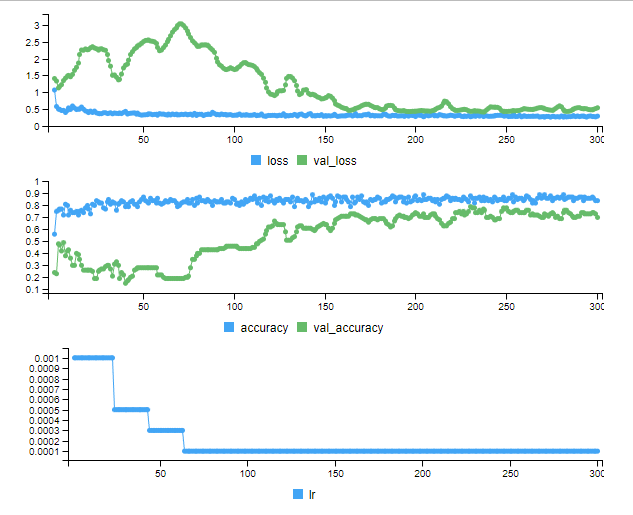

#### Confusion matrix

|  | 1 | 2 | 3 | 4 |
| --- | --- | --- | --- | --- |
| 1 | 24 | 0 | 0 | 0 |
| 2 | 0 | 29 | 0 | 0 |
| 3 | 0 | 0 | 13 | 15 |
| 4 | 0 | 0 | 5 | 14 |

#### Dane oryginalne

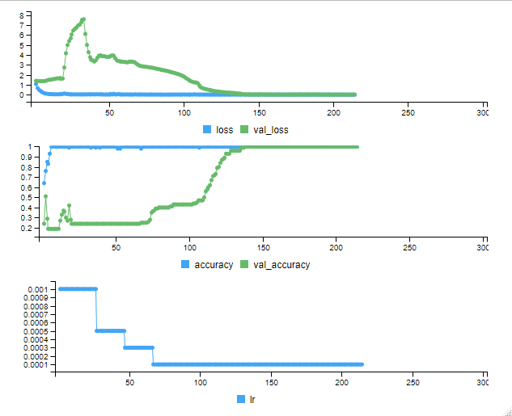

#### Confusion matrix

|  | 1 | 2 | 3 | 4 |
| --- | --- | --- | --- | --- |
| 1 | 24 | 0 | 0 | 0 |
| 2 | 0 | 29 | 0 | 0 |
| 3 | 0 | 0 | 28 | 0 |
| 4 | 0 | 0 | 0 | 19 |

### Car

#### Dane ucięte

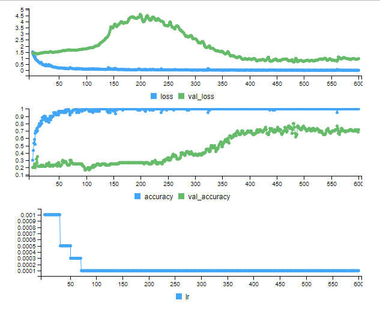

#### Confusion matrix

|  | 1 | 2 | 3 | 4 |
| --- | --- | --- | --- | --- |
| 1 | 13 | 0 | 1 | 0 |
| 2 | 2 | 11 | 1 | 0 |
| 3 | 1 | 0 | 17 | 1 |
| 4 | 1 | 0 | 3 | 9 |

#### Dane oryginalne

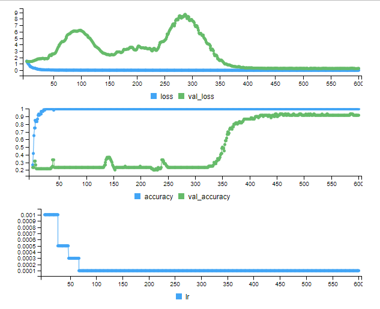

#### Confusion matrix

|  | 1 | 2 | 3 | 4 |
| --- | --- | --- | --- | --- |
| 1 | 14 | 0 | 0 | 0 |
| 2 | 0 | 14 | 0 | 0 |
| 3 | 0 | 1 | 15 | 3 |
| 4 | 0 | 0 | 4 | 9 |

#### Trening z użyciem innego wariantu sieci ResNet

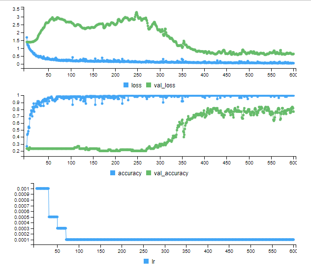

### Colposcopy

#### Dane ucięte

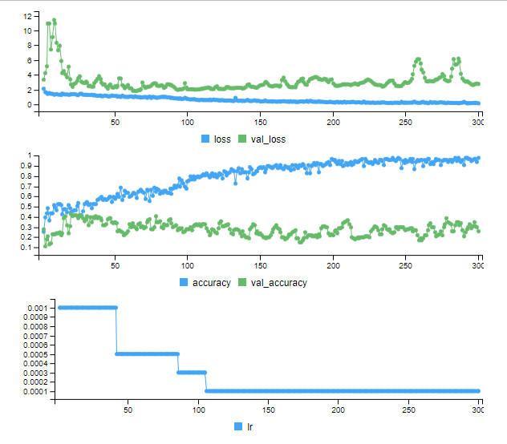

#### Confusion matrix

[output not shown]

#### Dane oryginalne

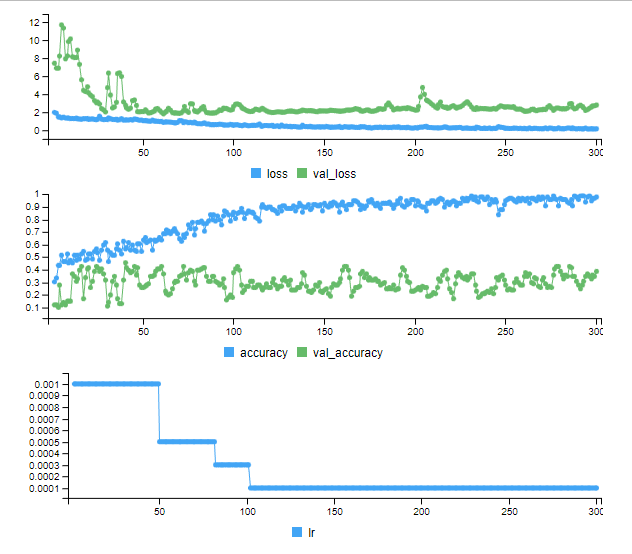

#### Confusion matrix

|  | 1 | 2 | 3 | 4 | 5 | 6 |
| --- | --- | --- | --- | --- | --- | --- |
| 1 | 0 | 0 | 0 | 7 | 0 | 1 |
| 2 | 0 | 0 | 0 | 7 | 2 | 3 |
| 3 | 0 | 0 | 0 | 3 | 2 | 5 |
| 4 | 1 | 0 | 1 | 16 | 2 | 4 |
| 5 | 0 | 0 | 1 | 8 | 3 | 7 |
| 6 | 3 | 1 | 0 | 3 | 4 | 15 |

##### Jest to relatywnie duży zbiór ważący około 20MB.

### Adiac

#### Dane ucięte

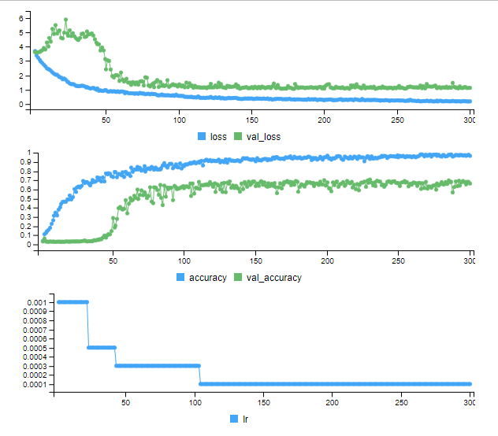

#### Confusion matrix

| 13 | 1 | 0 | 0 | 0 | 0 | 0 | 0 | 0 | 0 | 0 | 0 | 0 | 10 | 0 | 0 | 0 | 0 | 1 | 0 | 2 | 0 | 0 | 0 | 0 | 0 | 0 | 0 | 0 | 0 | … |
| --- | --- | --- | --- | --- | --- | --- | --- | --- | --- | --- | --- | --- | --- | --- | --- | --- | --- | --- | --- | --- | --- | --- | --- | --- | --- | --- | --- | --- | --- | --- |
| 14 | 0 | 0 | 0 | 0 | 0 | 0 | 0 | 0 | 0 | 0 | 0 | 0 | 0 | 5 | 0 | 0 | 0 | 0 | 0 | 0 | 0 | 0 | 0 | 1 | 1 | 0 | 0 | 0 | 0 | … |
| 15 | 0 | 0 | 0 | 0 | 0 | 0 | 0 | 0 | 0 | 0 | 0 | 0 | 0 | 0 | 7 | 0 | 0 | 0 | 0 | 0 | 1 | 0 | 0 | 0 | 0 | 0 | 0 | 0 | 0 | … |
| 16 | 0 | 0 | 0 | 0 | 0 | 0 | 0 | 0 | 0 | 0 | 0 | 0 | 0 | 0 | 0 | 10 | 0 | 0 | 0 | 0 | 0 | 0 | 0 | 0 | 0 | 0 | 0 | 0 | 0 | … |
| 17 | 0 | 0 | 0 | 0 | 0 | 0 | 0 | 0 | 0 | 0 | 0 | 0 | 0 | 0 | 0 | 0 | 9 | 0 | 0 | 0 | 0 | 0 | 0 | 0 | 0 | 0 | 0 | 0 | 0 | … |
| 18 | 0 | 0 | 0 | 1 | 0 | 0 | 0 | 0 | 0 | 0 | 0 | 0 | 0 | 0 | 0 | 0 | 0 | 11 | 0 | 0 | 0 | 0 | 0 | 0 | 1 | 0 | 0 | 0 | 0 | … |
| 19 | 0 | 0 | 0 | 0 | 0 | 0 | 2 | 0 | 0 | 0 | 0 | 0 | 0 | 1 | 0 | 0 | 0 | 0 | 5 | 0 | 0 | 0 | 0 | 0 | 2 | 0 | 0 | 0 | 0 | … |
| 20 | 0 | 0 | 0 | 0 | 0 | 0 | 0 | 3 | 0 | 0 | 0 | 0 | 0 | 0 | 0 | 0 | 0 | 0 | 0 | 3 | 3 | 0 | 0 | 0 | 0 | 2 | 0 | 1 | 0 | … |
| 21 | 2 | 0 | 0 | 0 | 0 | 0 | 0 | 0 | 0 | 0 | 0 | 0 | 0 | 0 | 0 | 0 | 0 | 0 | 0 | 0 | 11 | 0 | 0 | 0 | 0 | 0 | 1 | 0 | 0 | … |
| 22 | 0 | 0 | 0 | 0 | 0 | 0 | 0 | 1 | 0 | 0 | 0 | 0 | 0 | 0 | 0 | 0 | 0 | 0 | 1 | 0 | 0 | 2 | 0 | 0 | 1 | 0 | 0 | 0 | 0 | … |
| 23 | 0 | 0 | 0 | 0 | 0 | 0 | 0 | 0 | 0 | 0 | 0 | 0 | 1 | 0 | 0 | 0 | 0 | 1 | 0 | 0 | 0 | 0 | 6 | 0 | 0 | 0 | 0 | 0 | 0 | … |
| 24 | 0 | 0 | 0 | 0 | 0 | 0 | 0 | 0 | 0 | 0 | 0 | 0 | 0 | 0 | 0 | 0 | 0 | 0 | 0 | 0 | 0 | 0 | 0 | 8 | 0 | 0 | 0 | 0 | 0 | … |
| 25 | 0 | 0 | 0 | 0 | 0 | 0 | 0 | 0 | 0 | 0 | 0 | 0 | 0 | 0 | 0 | 0 | 0 | 2 | 0 | 0 | 0 | 0 | 0 | 0 | 13 | 0 | 0 | 0 | 0 | … |
| 26 | 0 | 0 | 0 | 0 | 0 | 0 | 0 | 1 | 0 | 0 | 0 | 0 | 0 | 0 | 0 | 0 | 0 | 1 | 0 | 1 | 0 | 0 | 0 | 0 | 1 | 7 | 0 | 0 | 0 | … |
| 27 | 0 | 0 | 0 | 0 | 0 | 0 | 0 | 0 | 0 | 0 | 0 | 0 | 0 | 0 | 0 | 0 | 0 | 0 | 0 | 0 | 0 | 0 | 0 | 0 | 0 | 0 | 6 | 0 | 0 | … |
| 28 | 2 | 0 | 0 | 0 | 0 | 0 | 0 | 0 | 0 | 0 | 0 | 0 | 0 | 0 | 0 | 0 | 0 | 0 | 0 | 0 | 0 | 0 | 0 | 0 | 0 | 0 | 0 | 3 | 1 | … |
| 29 | 0 | 0 | 0 | 0 | 0 | 0 | 0 | 1 | 0 | 0 | 0 | 0 | 0 | 1 | 0 | 0 | 0 | 0 | 0 | 0 | 0 | 0 | 0 | 0 | 0 | 0 | 0 | 0 | 8 | … |
| 30 | 0 | 0 | 0 | 0 | 0 | 0 | 0 | 0 | 0 | 0 | 0 | 0 | 0 | 0 | 0 | 0 | 0 | 0 | 0 | 0 | 0 | 0 | 0 | 1 | 0 | 0 | 0 | 0 | 2 | … |
| 31 | 2 | 0 | 0 | 0 | 0 | 0 | 0 | 0 | 0 | 0 | 0 | 0 | 0 | 0 | 1 | 0 | 0 | 0 | 0 | 0 | 0 | 0 | 0 | 0 | 0 | 0 | 0 | 4 | 1 | … |
| 32 | 0 | 0 | 0 | 0 | 0 | 0 | 0 | 1 | 0 | 0 | 0 | 0 | 0 | 0 | 0 | 0 | 0 | 0 | 0 | 0 | 0 | 0 | 0 | 0 | 0 | 0 | 1 | 0 | 0 | … |
| 33 | 0 | 0 | 0 | 0 | 0 | 0 | 0 | 0 | 0 | 0 | 0 | 0 | 0 | 0 | 0 | 0 | 0 | 0 | 0 | 0 | 0 | 0 | 1 | 0 | 0 | 0 | 0 | 0 | 0 | … |
| 34 | 0 | 0 | 0 | 0 | 0 | 0 | 0 | 0 | 0 | 0 | 1 | 0 | 0 | 0 | 0 | 0 | 0 | 0 | 0 | 0 | 0 | 0 | 1 | 0 | 0 | 0 | 0 | 2 | 0 | … |
| 35 | 0 | 0 | 0 | 0 | 2 | 0 | 0 | 0 | 0 | 0 | 0 | 0 | 0 | 0 | 0 | 0 | 0 | 0 | 0 | 0 | 0 | 0 | 0 | 0 | 0 | 0 | 0 | 0 | 0 | … |
| 36 | 0 | 0 | 0 | 0 | 0 | 0 | 0 | 0 | 0 | 0 | 0 | 3 | 0 | 0 | 0 | 0 | 0 | 0 | 0 | 0 | 0 | 0 | 0 | 0 | 0 | 0 | 0 | 0 | 0 | … |
| 37 | 0 | 0 | 0 | 0 | 0 | 0 | 0 | 1 | 0 | 0 | 0 | 0 | 0 | 0 | 0 | 0 | 0 | 0 | 0 | 0 | 0 | 0 | 0 | 1 | 0 | 0 | 0 | 0 | 3 | … |

#### Dane oryginalne

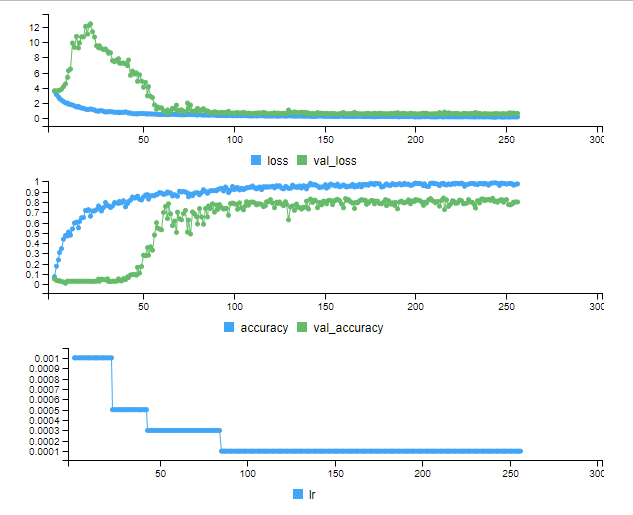

#### Confusion matrix

| 13 | 0 | 0 | 0 | 0 | 0 | 0 | 0 | 0 | 0 | 0 | 0 | 0 | 13 | 0 | 0 | 0 | 0 | 0 | 0 | 0 | 0 | 0 | 1 | 0 | 0 | 0 | 0 | 0 | 0 | … |
| --- | --- | --- | --- | --- | --- | --- | --- | --- | --- | --- | --- | --- | --- | --- | --- | --- | --- | --- | --- | --- | --- | --- | --- | --- | --- | --- | --- | --- | --- | --- |
| 14 | 0 | 0 | 0 | 0 | 0 | 0 | 0 | 0 | 0 | 0 | 0 | 0 | 0 | 8 | 0 | 0 | 0 | 0 | 0 | 0 | 0 | 0 | 0 | 0 | 0 | 0 | 0 | 0 | 0 | … |
| 15 | 0 | 0 | 0 | 0 | 0 | 0 | 0 | 0 | 0 | 0 | 0 | 0 | 0 | 0 | 9 | 0 | 0 | 0 | 0 | 0 | 0 | 0 | 0 | 0 | 0 | 0 | 0 | 0 | 0 | … |
| 16 | 0 | 0 | 0 | 0 | 0 | 0 | 0 | 0 | 0 | 0 | 0 | 0 | 0 | 0 | 0 | 10 | 0 | 0 | 0 | 0 | 0 | 0 | 0 | 0 | 0 | 0 | 0 | 0 | 0 | … |
| 17 | 0 | 0 | 0 | 0 | 0 | 0 | 0 | 0 | 0 | 0 | 0 | 0 | 0 | 0 | 0 | 0 | 9 | 0 | 0 | 0 | 0 | 0 | 0 | 0 | 0 | 0 | 0 | 0 | 0 | … |
| 18 | 0 | 0 | 0 | 0 | 0 | 0 | 0 | 0 | 0 | 0 | 0 | 0 | 0 | 0 | 0 | 0 | 0 | 12 | 0 | 1 | 0 | 0 | 0 | 0 | 0 | 0 | 0 | 0 | 0 | … |
| 19 | 0 | 0 | 0 | 0 | 1 | 0 | 0 | 0 | 0 | 0 | 0 | 0 | 0 | 0 | 0 | 0 | 0 | 0 | 9 | 0 | 0 | 1 | 0 | 0 | 0 | 0 | 0 | 0 | 0 | … |
| 20 | 0 | 0 | 0 | 0 | 0 | 0 | 0 | 0 | 0 | 0 | 0 | 0 | 0 | 0 | 0 | 0 | 0 | 0 | 0 | 11 | 0 | 0 | 0 | 0 | 0 | 1 | 0 | 0 | 0 | … |
| 21 | 0 | 0 | 0 | 0 | 0 | 0 | 0 | 0 | 0 | 0 | 0 | 0 | 0 | 0 | 0 | 0 | 0 | 0 | 0 | 0 | 12 | 0 | 0 | 0 | 0 | 0 | 0 | 0 | 0 | … |
| 22 | 0 | 0 | 0 | 0 | 0 | 0 | 0 | 0 | 0 | 0 | 0 | 0 | 0 | 0 | 0 | 0 | 0 | 0 | 0 | 0 | 0 | 7 | 0 | 0 | 0 | 0 | 0 | 0 | 1 | … |
| 23 | 0 | 0 | 0 | 0 | 0 | 0 | 0 | 0 | 0 | 0 | 0 | 0 | 1 | 0 | 0 | 0 | 0 | 1 | 0 | 0 | 0 | 0 | 8 | 0 | 0 | 0 | 0 | 0 | 0 | … |
| 24 | 0 | 0 | 0 | 0 | 0 | 0 | 0 | 0 | 0 | 0 | 0 | 0 | 0 | 0 | 0 | 0 | 0 | 0 | 0 | 0 | 0 | 0 | 0 | 8 | 0 | 0 | 0 | 0 | 0 | … |
| 25 | 0 | 0 | 0 | 0 | 0 | 0 | 0 | 0 | 0 | 0 | 0 | 0 | 0 | 0 | 0 | 0 | 0 | 0 | 0 | 0 | 0 | 0 | 0 | 0 | 15 | 1 | 0 | 0 | 0 | … |
| 26 | 0 | 0 | 0 | 0 | 0 | 0 | 0 | 0 | 0 | 0 | 0 | 0 | 0 | 0 | 0 | 0 | 0 | 0 | 0 | 2 | 0 | 0 | 0 | 0 | 1 | 8 | 0 | 0 | 0 | … |
| 27 | 0 | 0 | 0 | 0 | 0 | 0 | 0 | 0 | 0 | 0 | 0 | 0 | 0 | 0 | 0 | 0 | 0 | 0 | 0 | 0 | 0 | 0 | 0 | 0 | 0 | 0 | 7 | 0 | 0 | … |
| 28 | 1 | 0 | 0 | 0 | 0 | 0 | 0 | 0 | 0 | 0 | 0 | 0 | 0 | 0 | 0 | 0 | 0 | 0 | 0 | 0 | 0 | 1 | 0 | 0 | 0 | 0 | 0 | 3 | 1 | … |
| 29 | 0 | 0 | 0 | 0 | 0 | 0 | 0 | 0 | 0 | 0 | 0 | 0 | 0 | 0 | 0 | 0 | 0 | 0 | 0 | 0 | 0 | 0 | 0 | 0 | 0 | 0 | 0 | 0 | 11 | … |
| 30 | 0 | 0 | 0 | 0 | 0 | 0 | 0 | 0 | 0 | 0 | 0 | 0 | 0 | 0 | 0 | 0 | 0 | 0 | 0 | 0 | 0 | 0 | 0 | 0 | 0 | 0 | 1 | 0 | 0 | … |
| 31 | 0 | 0 | 0 | 0 | 0 | 0 | 0 | 0 | 0 | 0 | 0 | 0 | 0 | 0 | 1 | 0 | 0 | 0 | 0 | 0 | 0 | 0 | 1 | 0 | 0 | 0 | 0 | 7 | 0 | … |
| 32 | 0 | 0 | 0 | 0 | 0 | 0 | 0 | 0 | 0 | 0 | 0 | 0 | 0 | 0 | 0 | 0 | 0 | 0 | 0 | 0 | 0 | 0 | 0 | 0 | 0 | 0 | 0 | 0 | 0 | … |
| 33 | 0 | 0 | 0 | 0 | 0 | 0 | 0 | 0 | 0 | 0 | 0 | 0 | 0 | 0 | 0 | 0 | 0 | 0 | 0 | 0 | 0 | 0 | 0 | 0 | 0 | 0 | 0 | 0 | 0 | … |
| 34 | 0 | 0 | 0 | 0 | 0 | 0 | 0 | 0 | 0 | 0 | 0 | 0 | 0 | 0 | 0 | 0 | 0 | 0 | 0 | 0 | 0 | 0 | 1 | 0 | 0 | 0 | 0 | 0 | 0 | … |
| 35 | 0 | 0 | 0 | 0 | 1 | 0 | 0 | 0 | 0 | 0 | 0 | 0 | 0 | 0 | 0 | 0 | 0 | 0 | 0 | 0 | 0 | 0 | 0 | 0 | 0 | 0 | 0 | 0 | 0 | … |
| 36 | 0 | 0 | 0 | 0 | 0 | 0 | 0 | 0 | 0 | 0 | 0 | 2 | 0 | 0 | 0 | 0 | 0 | 0 | 0 | 0 | 0 | 0 | 0 | 0 | 0 | 0 | 0 | 0 | 0 | … |
| 37 | 0 | 0 | 0 | 0 | 0 | 0 | 0 | 0 | 0 | 0 | 0 | 0 | 0 | 0 | 0 | 0 | 0 | 0 | 0 | 0 | 0 | 1 | 0 | 0 | 0 | 0 | 0 | 1 | 0 | … |

##### Jest to zbiór o 37 różnych klasach.

### CricketX

#### Dane ucięte

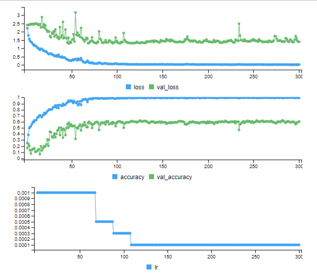

#### Confusion matrix

|  | 1 | 2 | 3 | 4 | 5 | 6 | 7 | 8 | 9 | 10 | 11 | 12 |
| --- | --- | --- | --- | --- | --- | --- | --- | --- | --- | --- | --- | --- |
| 1 | 19 | 1 | 1 | 0 | 0 | 0 | 0 | 0 | 4 | 1 | 1 | 0 |
| 2 | 2 | 27 | 0 | 1 | 0 | 0 | 1 | 0 | 0 | 0 | 0 | 3 |
| 3 | 1 | 0 | 27 | 0 | 0 | 0 | 1 | 1 | 0 | 0 | 1 | 0 |
| 4 | 0 | 0 | 0 | 25 | 0 | 0 | 0 | 1 | 0 | 2 | 2 | 0 |
| 5 | 1 | 1 | 0 | 1 | 35 | 0 | 0 | 0 | 0 | 0 | 0 | 0 |
| 6 | 2 | 2 | 0 | 0 | 1 | 10 | 1 | 1 | 1 | 6 | 2 | 5 |
| 7 | 2 | 1 | 0 | 0 | 0 | 0 | 25 | 0 | 0 | 0 | 0 | 1 |
| 8 | 0 | 0 | 0 | 0 | 0 | 0 | 0 | 12 | 0 | 15 | 3 | 3 |
| 9 | 9 | 2 | 1 | 0 | 0 | 0 | 2 | 1 | 19 | 0 | 2 | 4 |
| 10 | 1 | 1 | 0 | 0 | 1 | 2 | 0 | 6 | 0 | 21 | 2 | 3 |
| 11 | 2 | 1 | 1 | 0 | 0 | 1 | 0 | 1 | 0 | 1 | 19 | 1 |
| 12 | 1 | 0 | 0 | 1 | 0 | 3 | 1 | 3 | 0 | 3 | 4 | 17 |

#### Dane oryginalne

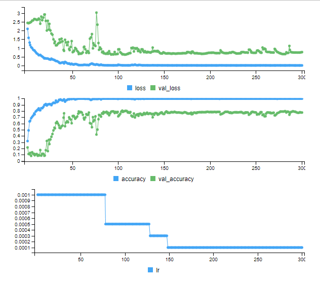

#### Confusion matrix

|  | 1 | 2 | 3 | 4 | 5 | 6 | 7 | 8 | 9 | 10 | 11 | 12 |
| --- | --- | --- | --- | --- | --- | --- | --- | --- | --- | --- | --- | --- |
| 1 | 24 | 0 | 0 | 0 | 0 | 0 | 0 | 0 | 3 | 0 | 0 | 0 |
| 2 | 1 | 32 | 0 | 0 | 0 | 0 | 0 | 0 | 0 | 0 | 0 | 1 |
| 3 | 0 | 0 | 29 | 0 | 0 | 0 | 0 | 0 | 0 | 0 | 2 | 0 |
| 4 | 0 | 0 | 0 | 29 | 0 | 0 | 0 | 0 | 1 | 0 | 0 | 0 |
| 5 | 0 | 0 | 0 | 0 | 38 | 0 | 0 | 0 | 0 | 0 | 0 | 0 |
| 6 | 1 | 2 | 0 | 0 | 0 | 11 | 0 | 3 | 0 | 2 | 0 | 12 |
| 7 | 1 | 0 | 0 | 0 | 0 | 0 | 28 | 0 | 0 | 0 | 0 | 0 |
| 8 | 0 | 0 | 0 | 0 | 0 | 1 | 0 | 19 | 0 | 10 | 1 | 3 |
| 9 | 10 | 2 | 0 | 0 | 0 | 0 | 2 | 0 | 25 | 0 | 0 | 1 |
| 10 | 0 | 0 | 0 | 0 | 0 | 1 | 0 | 4 | 0 | 24 | 3 | 5 |
| 11 | 0 | 1 | 0 | 0 | 0 | 0 | 0 | 1 | 0 | 0 | 23 | 1 |
| 12 | 0 | 0 | 0 | 0 | 1 | 1 | 0 | 3 | 0 | 1 | 3 | 24 |

#### Dane niewymieszane

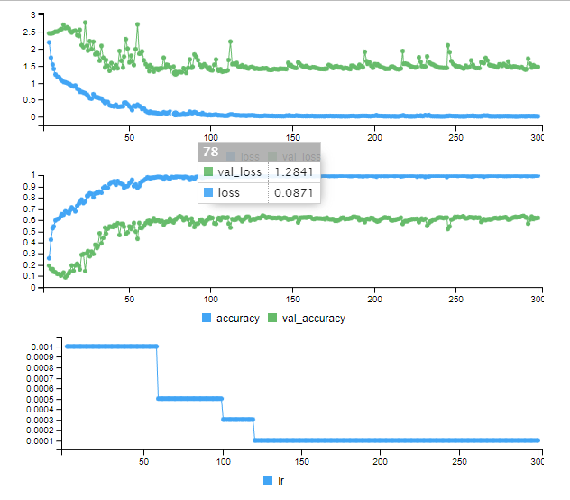

#### Dane ucięte z parametrem batch_size = 16

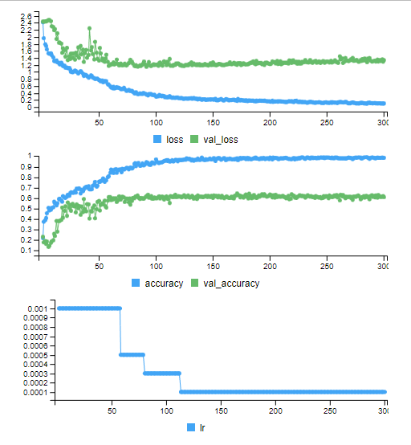

#### Dane ucięte z parametrem batch_size = 64

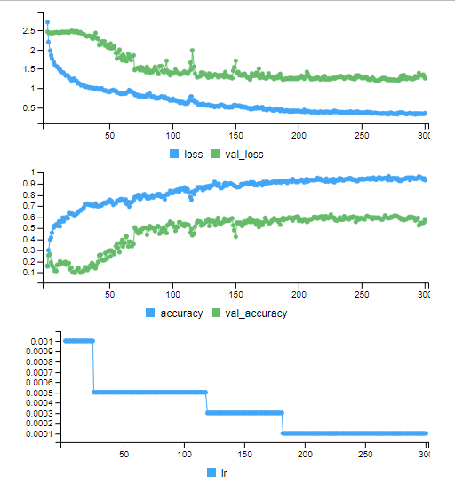